# SVC Item Norming

John Flournoy

Fri Oct 9 17:25:37 2015

# Descriptives

These histograms by themselves tell a really interesting story – you can see that there is a some overlap between Acc and Cont ratings, but some items distinguish between them. These line up with a lot of our *a priori* ideas – see anger and jealousy. Pretty cool.

Aside from the status items, you also can see the scores on depression and substance use, among other things. Keep in mind the middle 2 CES_D items are reverse coded. SES ladder is mostly between 3-7 on a 9 point scale.

[figure not shown]

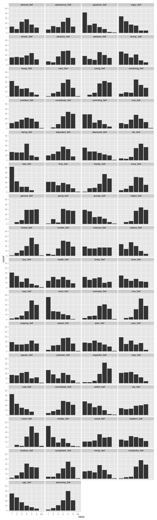

| desc | skew | pval | mean | sd |
| --- | --- | --- | --- | --- |
| insecure_Self | -0.0283501 | 0.9019713 | 3.490000 | 1.7551943 |
| daring_Self | -0.0369397 | 0.8725091 | 3.250000 | 1.4728177 |
| stubborn_Self | -0.0579809 | 0.8012135 | 3.490000 | 1.5858911 |
| leader_Self | 0.1027514 | 0.6559274 | 3.310000 | 1.5419717 |
| outgoing_Self | -0.1224289 | 0.5958376 | 3.550000 | 1.7602514 |
| popular_Self | 0.1436750 | 0.5359458 | 3.292929 | 1.5859879 |
| trendy_Self | -0.1445669 | 0.5334386 | 3.454546 | 1.5536181 |
| athletic_Self | -0.1573981 | 0.4961474 | 3.540000 | 1.6231905 |
| plain_Self | 0.1663235 | 0.4742817 | 3.232323 | 1.5896880 |
| pushover_Self | 0.1733206 | 0.4561013 | 3.010101 | 1.6567423 |
| confident_Self | -0.1805505 | 0.4377608 | 3.686869 | 1.5626147 |
| flirty_Self | 0.1910091 | 0.4120430 | 3.121212 | 1.6242595 |
| lonely_Self | 0.2134421 | 0.3580291 | 3.170000 | 1.6517820 |
| jealous_Self | 0.2166837 | 0.3509063 | 2.900000 | 1.4389952 |
| admired_Self | -0.2248039 | 0.3334858 | 3.610000 | 1.4832056 |
| loner_Self | 0.2408992 | 0.3007352 | 3.120000 | 1.7249213 |
| awkward_Self | -0.2509980 | 0.2813861 | 3.600000 | 1.6817499 |
| poor_Self | 0.2688930 | 0.2493376 | 2.840000 | 1.5486716 |
| dependent_Self | -0.3042124 | 0.1941856 | 3.650000 | 1.4310764 |
| risky_Self | 0.3162972 | 0.1776644 | 2.900000 | 1.4459976 |
| shy_Self | -0.3172830 | 0.1763672 | 3.850000 | 1.7196135 |
| cool_Self | -0.3321158 | 0.1595970 | 3.767677 | 1.4971284 |
| depressed_Self | 0.3563828 | 0.1324318 | 2.989899 | 1.6751177 |
| social_Self | -0.3708593 | 0.1164910 | 3.910000 | 1.6023657 |
| selfish_Self | 0.4277253 | 0.0737972 | 2.646465 | 1.4308063 |
| boring _Self | 0.4287829 | 0.0718664 | 2.770000 | 1.5166084 |
| patient_Self | -0.4599712 | 0.0557251 | 4.141414 | 1.3477881 |
| studious_Self | -0.4838010 | 0.0440607 | 4.370000 | 1.2764772 |
| adventurous_Self | -0.4871470 | 0.0427308 | 3.960000 | 1.4696938 |
| genuine_Self | -0.5502226 | 0.0235596 | 4.730000 | 1.0996326 |
| considerate_Self | -0.5567995 | 0.0221008 | 4.810000 | 1.0317681 |
| bossy_Self | 0.5578755 | 0.0218702 | 2.610000 | 1.5034976 |
| lazy_Self | 0.5746806 | 0.0190660 | 2.636364 | 1.5349968 |
| grumpy_Self | 0.5781332 | 0.0184309 | 2.646465 | 1.5139699 |
| caring_Self | -0.6049512 | 0.0137084 | 4.740000 | 1.0882290 |
| attractive_Self | -0.6192752 | 0.0118559 | 4.090000 | 1.3640033 |
| comforting_Self | -0.6278347 | 0.0108637 | 4.160000 | 1.3905889 |
| funny_Self | -0.6287765 | 0.0107594 | 4.210000 | 1.2815316 |
| rule-follower_Self | -0.6307734 | 0.0105414 | 4.300000 | 1.3521401 |
| controlling_Self | 0.6337901 | 0.0102200 | 2.600000 | 1.4839206 |
| calm_Self | -0.6507185 | 0.0088741 | 4.444444 | 1.1712737 |
| humble_Self | -0.6776478 | 0.0064745 | 4.360000 | 1.2351747 |
| helpful_Self | -0.6789290 | 0.0063877 | 4.780000 | 1.0596359 |
| agressive_Self | 0.7324172 | 0.0037556 | 2.333333 | 1.4356965 |
| giving_Self | -0.7483863 | 0.0030331 | 4.560000 | 1.2578642 |
| snobby_Self | 0.7502175 | 0.0031001 | 2.323232 | 1.4765395 |
| angry_Self | 0.7731570 | 0.0023127 | 2.480000 | 1.4666667 |
| honest_Self | -0.7748193 | 0.0023727 | 4.595960 | 1.2030505 |
| motivated_Self | -0.7847003 | 0.0021295 | 4.444444 | 1.2874767 |
| rude_Self | 0.8024367 | 0.0016730 | 2.170000 | 1.2953296 |
| mean_Self | 0.8178574 | 0.0014088 | 2.230000 | 1.4131775 |
| nice_Self | -0.8676875 | 0.0008039 | 4.880000 | 0.9773185 |
| welcoming_Self | -0.8746451 | 0.0007429 | 4.550000 | 1.2007994 |
| friendly_Self | -0.8770667 | 0.0007227 | 4.650000 | 1.2583057 |
| ugly_Self | 0.9027683 | 0.0005391 | 2.390000 | 1.4347421 |
| sympathetic_Self | -0.9293323 | 0.0004210 | 4.525252 | 1.3041804 |
| trustworthy_Self | -1.0070150 | 0.0001616 | 4.830000 | 1.0546195 |
| smart_Self | -1.0217586 | 0.0001552 | 4.918367 | 0.9809891 |
| fair_Self | -1.0710441 | 0.0000764 | 4.630000 | 1.2605514 |
| fake_Self | 1.0872091 | 0.0000632 | 1.930000 | 1.1997895 |
| loyal_Self | -1.1144612 | 0.0000458 | 4.770000 | 1.1964172 |
| respectful_Self | -1.2988493 | 0.0000052 | 4.870000 | 1.0885539 |

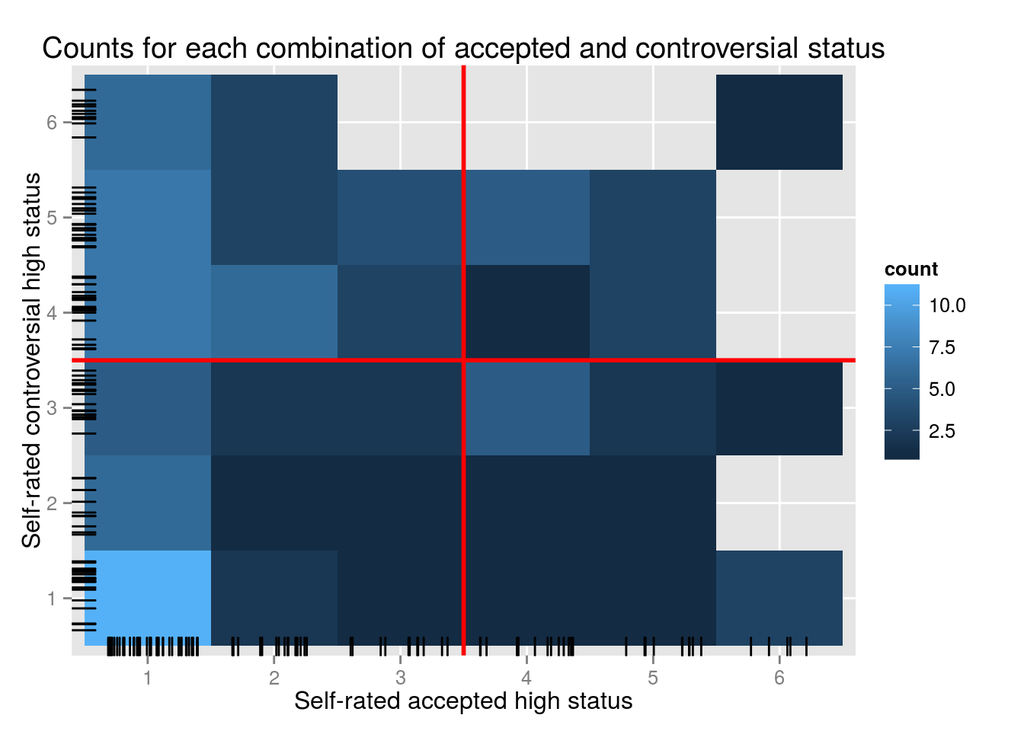

Controversial versus Accepted Status Frequencies

| Cont_v_Acc | 1 | 2 | 3 | 4 | 5 | 6 |
| --- | --- | --- | --- | --- | --- | --- |
| 1 | 11 | 6 | 5 | 7 | 7 | 6 |
| 2 | 2 | 1 | 2 | 6 | 3 | 3 |
| 3 | 1 | 1 | 2 | 3 | 4 | 0 |
| 4 | 1 | 1 | 5 | 1 | 5 | 0 |
| 5 | 1 | 1 | 2 | 3 | 3 | 0 |
| 6 | 3 | 0 | 1 | 0 | 0 | 1 |

# Self Ratings

## EFA to look at latent constructs

The more traditional approach would be to use EFA. What we hope to get is 2 factors the correspond to Accepted High Status and Controversial High Status.

However, the scree plot shows *very* clearly a 3 factor solution will account for most of the variance, with no real gain if we increase beyond 4.

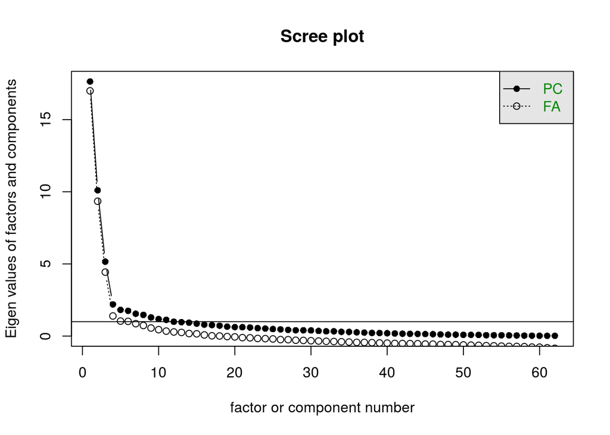

Here’s the raw output, if you like, but see below for a prettier table. Notice the factors are allowed to correlate.

```
## Factor Analysis using method =  pa
## Call: fa(r = select(selfRateDat, -matches("SelfPop")), nfactors = 3,
##     rotate = "oblimin", scores = "tenBerge", fm = "pa", use = "pairwise.complete.obs")
## Standardized loadings (pattern matrix) based upon correlation matrix
##                    item   PA3   PA1   PA2   h2   u2 com
## insecure_Self        31 -0.86             0.72 0.28 1.1
## lonely_Self          35 -0.84             0.69 0.31 1.3
## depressed_Self       19 -0.82        0.29 0.69 0.31 1.3
## loner_Self           36 -0.79             0.64 0.36 1.0
## awkward_Self          7 -0.78             0.59 0.41 1.3
## confident_Self       13  0.77             0.74 0.26 1.2
## trendy_Self          59  0.76             0.67 0.33 1.2
## shy_Self             52 -0.73             0.49 0.51 1.2
## popular_Self         45  0.72             0.73 0.27 1.5
## social_Self          55  0.71             0.71 0.29 1.5
## plain_Self           43 -0.67             0.42 0.58 1.1
## flirty_Self          22  0.64             0.51 0.49 1.4
## boring _Self          8 -0.64             0.46 0.54 1.3
## admired_Self          1  0.62        0.36 0.65 0.35 2.0
## outgoing_Self        41  0.62             0.52 0.48 1.4
## attractive_Self       6  0.61  0.33       0.63 0.37 1.8
## cool_Self            16  0.60        0.41 0.68 0.32 2.2
## ugly_Self            61 -0.59             0.47 0.53 1.4
## leader_Self          34  0.57        0.32 0.49 0.51 1.7
## pushover_Self        46 -0.57             0.35 0.65 1.3
## adventurous_Self      2  0.50  0.29  0.33 0.51 0.49 2.4
## funny_Self           24  0.49  0.30       0.43 0.57 1.9
## poor_Self            44 -0.46        0.33 0.45 0.55 2.3
## daring_Self          17  0.43        0.38 0.36 0.64 2.0
## athletic_Self         5  0.31             0.17 0.83 1.9
## nice_Self            40        0.84       0.73 0.27 1.0
## considerate_Self     14        0.83       0.69 0.31 1.1
## helpful_Self         28        0.79       0.66 0.34 1.0
## genuine_Self         25        0.77       0.58 0.42 1.0
## caring_Self          11        0.76       0.59 0.41 1.0
## loyal_Self           37        0.74       0.51 0.49 1.1
## friendly_Self        23        0.72       0.59 0.41 1.1
## trustworthy_Self     60        0.72       0.58 0.42 1.0
## giving_Self          26        0.71       0.52 0.48 1.0
## sympathetic_Self     58        0.71       0.52 0.48 1.0
```

[output cut: 47 more lines]

```
## The root mean square of the residuals (RMSR) is  0.06
## The df corrected root mean square of the residuals is  0.06
##
## The harmonic number of observations is  99 with the empirical chi square  1373.9  with prob <  1
## The total number of observations was  100  with MLE Chi Square =  2583.27  with prob <  6.4e-39
##
## Tucker Lewis Index of factoring reliability =  0.727
## RMSEA index =  0.1  and the 90 % confidence intervals are  0.066 NA
## BIC =  -5282.36
## Fit based upon off diagonal values = 0.97
## Measures of factor score adequacy
##                                                 PA3  PA1  PA2
## Correlation of scores with factors             0.99 0.98 0.98
## Multiple R square of scores with factors       0.97 0.96 0.96
## Minimum correlation of possible factor scores  0.95 0.93 0.91
```

There are no items with really poor loadings on all three factors, but there are a lot with high cross loadings. Anything > .3 is potentially suspect (even that is a little liberal). I’ve pulled out 13 such items:

```
admired_Self          1  0.62  0.25  0.36 0.65 0.35 2.0
cool_Self            16  0.60  0.27  0.41 0.68 0.32 2.2
leader_Self          34  0.57  0.12  0.32 0.49 0.51 1.7
adventurous_Self      2  0.50  0.29  0.33 0.51 0.49 2.4
poor_Self            44 -0.46 -0.22  0.33 0.45 0.55 2.3
daring_Self          17  0.43  0.08  0.38 0.36 0.64 2.0
comforting_Self      12  0.34  0.44  0.00 0.40 0.60 1.9
angry_Self            4 -0.32 -0.09  0.71 0.64 0.36 1.4
grumpy_Self          27 -0.42 -0.05  0.66 0.62 0.38 1.7
jealous_Self         32 -0.39  0.02  0.56 0.44 0.56 1.8
patient_Self         42  0.13  0.43 -0.27 0.36 0.64 1.9
mean_Self            38  0.01 -0.32  0.70 0.67 0.33 1.4
fake_Self            21 -0.14 -0.40  0.48 0.51 0.49 2.1
```

## Some modifications

We can try again after dropping items with too much noise/cross loading

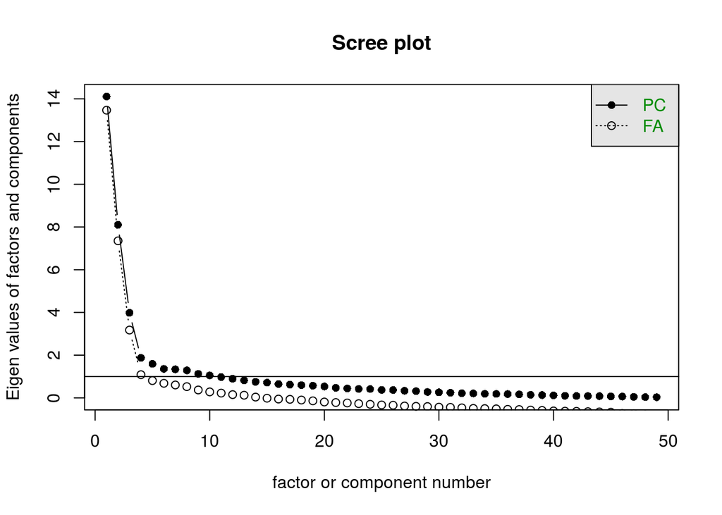

```
## Factor Analysis using method =  pa
## Call: fa(r = select(selfRateDat_lim, -matches("SelfPop")), nfactors = 3,
##     rotate = "oblimin", scores = "tenBerge", fm = "pa", use = "pairwise.complete.obs")
## Standardized loadings (pattern matrix) based upon correlation matrix
##                    item   PA1   PA3   PA2   h2   u2 com
## considerate_Self     10  0.84             0.68 0.32 1.1
## nice_Self            29  0.84             0.71 0.29 1.0
## helpful_Self         20  0.80             0.64 0.36 1.0
## caring_Self           8  0.77             0.60 0.40 1.0
## genuine_Self         18  0.77             0.58 0.42 1.0
## friendly_Self        16  0.74             0.58 0.42 1.0
## loyal_Self           27  0.74             0.50 0.50 1.1
## trustworthy_Self     47  0.73             0.59 0.41 1.0
## giving_Self          19  0.72             0.52 0.48 1.0
## sympathetic_Self     45  0.72             0.54 0.46 1.0
## welcoming_Self       49  0.68             0.58 0.42 1.2
## fair_Self            14  0.60             0.49 0.51 1.3
## respectful_Self      34  0.59             0.36 0.64 1.0
## calm_Self             7  0.57             0.42 0.58 1.2
## humble_Self          22  0.55             0.38 0.62 1.7
## honest_Self          21  0.52             0.40 0.60 1.4
## motivated_Self       28  0.49             0.30 0.70 1.2
## studious_Self        44  0.48             0.22 0.78 1.1
## rule-follower_Self   37  0.48             0.22 0.78 1.4
## smart_Self           40  0.46             0.24 0.76 1.1
## insecure_Self        23        0.88       0.72 0.28 1.0
## lonely_Self          25        0.87       0.69 0.31 1.1
## depressed_Self       13        0.85       0.68 0.32 1.1
## awkward_Self          4        0.82       0.61 0.39 1.2
## loner_Self           26        0.79       0.66 0.34 1.0
## shy_Self             39        0.70       0.47 0.53 1.2
## plain_Self           31        0.70       0.45 0.55 1.0
## confident_Self        9       -0.69       0.72 0.28 1.5
## boring _Self          5        0.68       0.49 0.51 1.1
## trendy_Self          46       -0.67  0.36 0.69 0.31 1.6
## social_Self          42       -0.63  0.37 0.73 0.27 2.0
## popular_Self         32       -0.62  0.36 0.73 0.27 2.0
## pushover_Self        33        0.60       0.35 0.65 1.2
## ugly_Self            48        0.59       0.46 0.54 1.3
## flirty_Self          15       -0.55  0.39 0.53 0.47 1.9
```

[output cut: 34 more lines]

```
## The root mean square of the residuals (RMSR) is  0.06
## The df corrected root mean square of the residuals is  0.06
##
## The harmonic number of observations is  99 with the empirical chi square  822.03  with prob <  1
## The total number of observations was  100  with MLE Chi Square =  1551.46  with prob <  1.3e-23
##
## Tucker Lewis Index of factoring reliability =  0.778
## RMSEA index =  0.093  and the 90 % confidence intervals are  0.064 NA
## BIC =  -3201.08
## Fit based upon off diagonal values = 0.97
## Measures of factor score adequacy
##                                                 PA1  PA3  PA2
## Correlation of scores with factors             0.98 0.98 0.97
## Multiple R square of scores with factors       0.96 0.97 0.94
## Minimum correlation of possible factor scores  0.92 0.93 0.88
```

There are still some bad items:

```
athletic_Self         2  0.20 -0.24  0.14 0.15 0.85 2.6
funny_Self           17  0.32 -0.44  0.20 0.43 0.57 2.3
attractive_Self       3  0.36 -0.52  0.31 0.62 0.38 2.5
dependent_Self       12  0.17  0.35  0.37 0.20 0.80 2.4
```

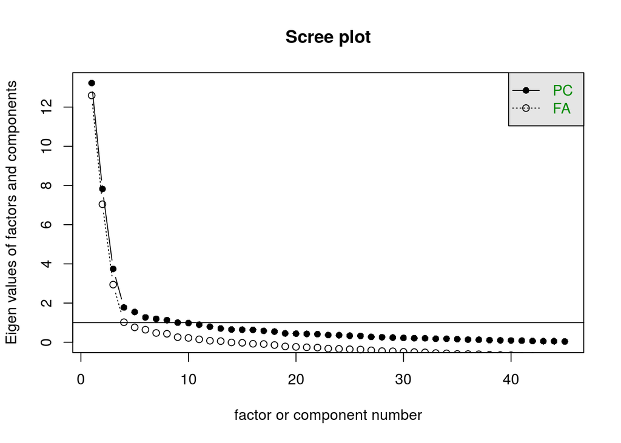

```
## Factor Analysis using method =  pa
## Call: fa(r = select(selfRateDat_lim2, -matches("SelfPop")), nfactors = 3,
##     rotate = "oblimin", scores = "tenBerge", fm = "pa", use = "pairwise.complete.obs")
## Standardized loadings (pattern matrix) based upon correlation matrix
##                    item   PA1   PA2   PA3   h2   u2 com
## nice_Self            25  0.84             0.71 0.29 1.0
## considerate_Self      8  0.84             0.68 0.32 1.1
## helpful_Self         16  0.79             0.63 0.37 1.0
## caring_Self           6  0.78             0.60 0.40 1.0
## genuine_Self         14  0.77             0.58 0.42 1.0
## friendly_Self        13  0.75             0.59 0.41 1.0
## loyal_Self           23  0.74             0.50 0.50 1.1
## trustworthy_Self     43  0.73             0.57 0.43 1.0
## sympathetic_Self     41  0.72             0.54 0.46 1.0
## giving_Self          15  0.72             0.52 0.48 1.0
## welcoming_Self       45  0.68             0.59 0.41 1.2
## fair_Self            11  0.62             0.49 0.51 1.2
## respectful_Self      30  0.58             0.36 0.64 1.0
## calm_Self             5  0.57             0.41 0.59 1.2
## humble_Self          18  0.55             0.38 0.62 1.7
## honest_Self          17  0.53             0.40 0.60 1.4
## motivated_Self       24  0.50             0.30 0.70 1.1
## rule-follower_Self   33  0.48             0.22 0.78 1.3
## studious_Self        40  0.47             0.22 0.78 1.1
## smart_Self           36  0.45             0.23 0.77 1.1
## insecure_Self        19        0.89       0.74 0.26 1.0
## lonely_Self          21        0.87       0.70 0.30 1.1
## depressed_Self       10        0.84       0.68 0.32 1.1
## awkward_Self          2        0.83       0.63 0.37 1.2
## loner_Self           22        0.79       0.67 0.33 1.0
## plain_Self           27        0.70       0.45 0.55 1.0
## shy_Self             35        0.67       0.46 0.54 1.2
## confident_Self        7       -0.67       0.73 0.27 1.6
## boring _Self          3        0.67       0.48 0.52 1.1
## trendy_Self          42       -0.66  0.38 0.69 0.31 1.7
## social_Self          38       -0.61  0.38 0.72 0.28 2.1
## popular_Self         28       -0.60  0.39 0.73 0.27 2.2
## pushover_Self        29        0.59       0.34 0.66 1.2
## ugly_Self            44        0.57       0.45 0.55 1.3
## flirty_Self          12       -0.54  0.40 0.54 0.46 1.9
```

[output cut: 30 more lines]

```
## The root mean square of the residuals (RMSR) is  0.06
## The df corrected root mean square of the residuals is  0.06
##
## The harmonic number of observations is  99 with the empirical chi square  658.67  with prob <  1
## The total number of observations was  100  with MLE Chi Square =  1286.33  with prob <  1e-19
##
## Tucker Lewis Index of factoring reliability =  0.801
## RMSEA index =  0.091  and the 90 % confidence intervals are  0.063 NA
## BIC =  -2664.91
## Fit based upon off diagonal values = 0.97
## Measures of factor score adequacy
##                                                 PA1  PA2  PA3
## Correlation of scores with factors             0.98 0.98 0.97
## Multiple R square of scores with factors       0.96 0.97 0.93
## Minimum correlation of possible factor scores  0.92 0.93 0.86
```

This should finish off our cleaning:

```
trendy_Self          42  0.11 -0.66  0.38 0.69 0.31 1.7
social_Self          38  0.27 -0.61  0.38 0.72 0.28 2.1
popular_Self         28  0.29 -0.60  0.39 0.73 0.27 2.2
flirty_Self          12  0.10 -0.54  0.40 0.54 0.46 1.9
outgoing_Self        26  0.19 -0.53  0.34 0.52 0.48 2.0
```

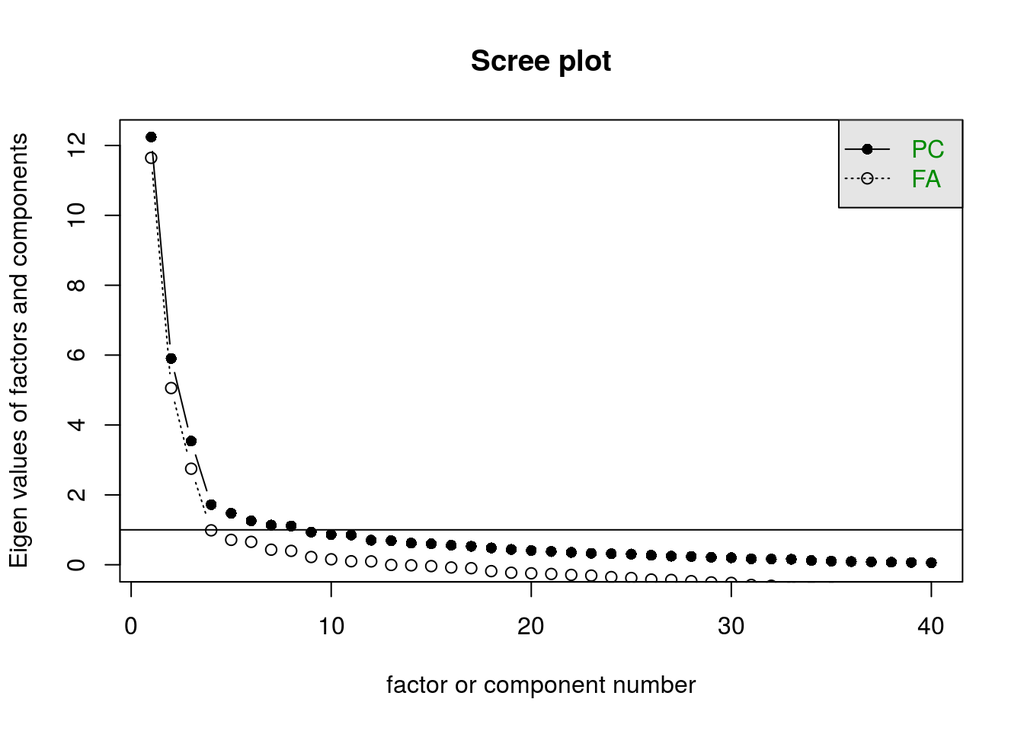

```
## Factor Analysis using method =  pa
## Call: fa(r = select(selfRateDat_lim3, -matches("SelfPop")), nfactors = 3,
##     rotate = "oblimin", scores = "tenBerge", fm = "pa", use = "pairwise.complete.obs")
## Standardized loadings (pattern matrix) based upon correlation matrix
##                    item   PA1   PA2   PA3   h2   u2 com
## considerate_Self      8  0.82             0.68 0.32 1.1
## nice_Self            24  0.82             0.71 0.29 1.0
## helpful_Self         15  0.80             0.63 0.37 1.0
## genuine_Self         13  0.78             0.59 0.41 1.0
## caring_Self           6  0.78             0.60 0.40 1.0
## friendly_Self        12  0.76             0.59 0.41 1.0
## trustworthy_Self     38  0.75             0.59 0.41 1.0
## loyal_Self           22  0.74             0.50 0.50 1.1
## giving_Self          14  0.72             0.51 0.49 1.0
## sympathetic_Self     37  0.71             0.54 0.46 1.0
## welcoming_Self       40  0.68             0.59 0.41 1.1
## fair_Self            11  0.60             0.49 0.51 1.2
## respectful_Self      27  0.58             0.36 0.64 1.0
## calm_Self             5  0.57             0.41 0.59 1.1
## honest_Self          16  0.53             0.40 0.60 1.3
## humble_Self          17  0.51             0.38 0.62 1.8
## motivated_Self       23  0.51             0.30 0.70 1.1
## studious_Self        36  0.47             0.22 0.78 1.1
## rule-follower_Self   30  0.46             0.22 0.78 1.4
## smart_Self           33  0.46             0.23 0.77 1.0
## insecure_Self        18        0.87       0.74 0.26 1.0
## lonely_Self          20        0.86       0.71 0.29 1.0
## depressed_Self       10        0.82       0.68 0.32 1.0
## awkward_Self          2        0.81       0.62 0.38 1.1
## loner_Self           21        0.78       0.68 0.32 1.1
## plain_Self           25        0.70       0.47 0.53 1.0
## shy_Self             32        0.66       0.46 0.54 1.2
## boring _Self          3        0.66       0.48 0.52 1.1
## confident_Self        7  0.31 -0.66  0.31 0.68 0.32 1.9
## pushover_Self        26        0.60       0.36 0.64 1.1
## ugly_Self            39        0.59       0.48 0.52 1.3
## controlling_Self      9              0.84 0.66 0.34 1.1
## bossy_Self            4              0.83 0.68 0.32 1.0
## agressive_Self        1              0.68 0.56 0.44 1.1
## snobby_Self          34              0.67 0.63 0.37 1.3
```

[output cut: 25 more lines]

```
## The root mean square of the residuals (RMSR) is  0.06
## The df corrected root mean square of the residuals is  0.06
##
## The harmonic number of observations is  99 with the empirical chi square  553.1  with prob <  1
## The total number of observations was  100  with MLE Chi Square =  1013.97  with prob <  3.7e-17
##
## Tucker Lewis Index of factoring reliability =  0.801
## RMSEA index =  0.091  and the 90 % confidence intervals are  0.064 NA
## BIC =  -2039.26
## Fit based upon off diagonal values = 0.97
## Measures of factor score adequacy
##                                                 PA1  PA2  PA3
## Correlation of scores with factors             0.98 0.97 0.96
## Multiple R square of scores with factors       0.96 0.95 0.92
## Minimum correlation of possible factor scores  0.91 0.90 0.83
```

After three rounds of item exclusion, we come up with a pretty clear factor structure.

1. PA1: Prosocial, girl scout.
2. PA2: Depressed, submissive, negative.
3. PA3: Anti-social, dominant, aggressive.

### Scale scores

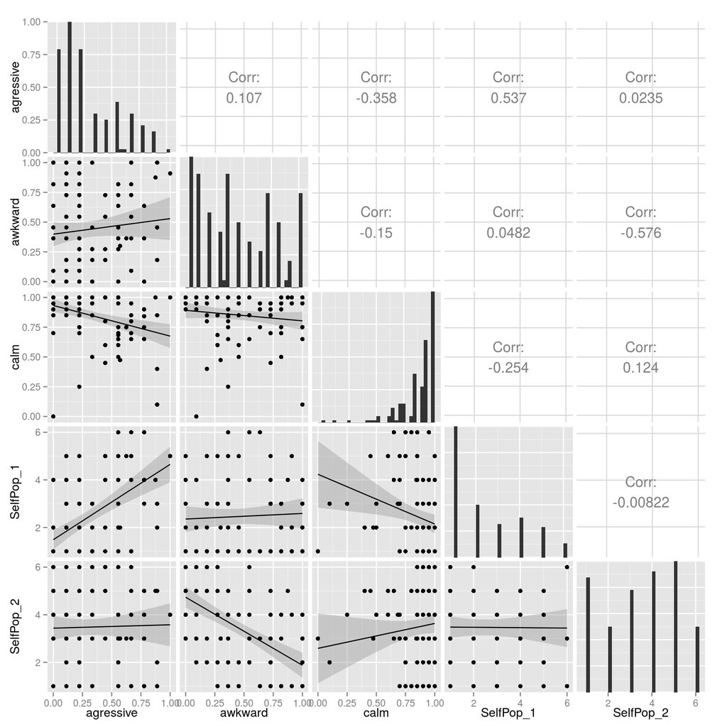

## Retry eliminating items

It’s too bad, I forgot to remove the overly skewed items first.

They include:

- nice_Self
- welcoming_Self
- friendly_Self
- ugly_Self
- sympathetic_Self
- trustworthy_Self
- smart_Self
- fair_Self
- fake_Self
- loyal_Self
- respectful_Self

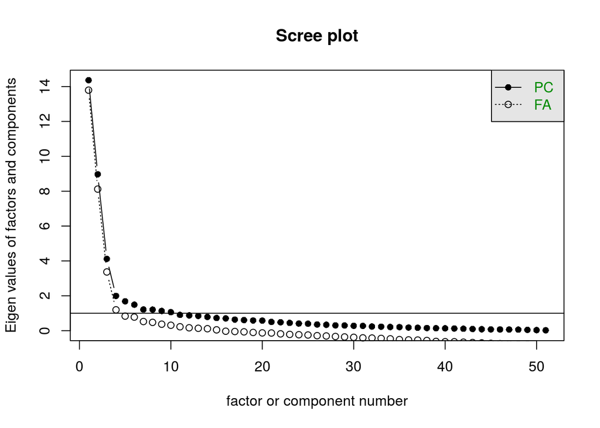

```
## Factor Analysis using method =  pa
## Call: fa(r = select(selfRateDat_lim, -matches("SelfPop")), nfactors = 3,
##     rotate = "oblimin", scores = "tenBerge", fm = "pa", use = "pairwise.complete.obs")
## Standardized loadings (pattern matrix) based upon correlation matrix
##                    item   PA1   PA2   PA3   h2   u2 com
## insecure_Self        28 -0.86             0.73 0.27 1.1
## lonely_Self          32 -0.83             0.69 0.31 1.3
## depressed_Self       19 -0.81  0.30       0.69 0.31 1.3
## loner_Self           33 -0.79             0.64 0.36 1.0
## confident_Self       13  0.77             0.74 0.26 1.2
## awkward_Self          7 -0.77             0.59 0.41 1.3
## trendy_Self          51  0.77             0.68 0.32 1.2
## shy_Self             46 -0.74             0.50 0.50 1.2
## social_Self          48  0.73             0.71 0.29 1.4
## popular_Self         40  0.73             0.73 0.27 1.4
## plain_Self           38 -0.68             0.44 0.56 1.1
## flirty_Self          20  0.65             0.51 0.49 1.3
## boring _Self          8 -0.64             0.45 0.55 1.3
## outgoing_Self        36  0.63             0.52 0.48 1.3
## admired_Self          1  0.62  0.33       0.66 0.34 2.0
## attractive_Self       6  0.61        0.32 0.62 0.38 1.7
## cool_Self            16  0.60  0.37  0.32 0.69 0.31 2.2
## leader_Self          31  0.57  0.30       0.49 0.51 1.7
## pushover_Self        41 -0.56             0.33 0.67 1.3
## adventurous_Self      2  0.52             0.50 0.50 2.2
## funny_Self           21  0.51             0.42 0.58 1.6
## poor_Self            39 -0.46  0.36       0.45 0.55 2.3
## daring_Self          17  0.44  0.36       0.36 0.64 2.0
## athletic_Self         5  0.30             0.19 0.81 2.0
## snobby_Self          47        0.76       0.66 0.34 1.2
## controlling_Self     15        0.74       0.62 0.38 1.2
## bossy_Self            9        0.74       0.62 0.38 1.2
## angry_Self            4 -0.31  0.74       0.65 0.35 1.4
## rude_Self            43        0.73       0.64 0.36 1.2
## mean_Self            34        0.73 -0.29 0.68 0.32 1.3
## agressive_Self        3        0.69       0.56 0.44 1.2
## grumpy_Self          24 -0.41  0.69       0.63 0.37 1.6
## selfish_Self         45        0.64       0.53 0.47 1.3
## jealous_Self         29 -0.37  0.56       0.43 0.57 1.7
## lazy_Self            30        0.52       0.33 0.67 1.3
```

[output cut: 36 more lines]

```
## The root mean square of the residuals (RMSR) is  0.06
## The df corrected root mean square of the residuals is  0.06
##
## The harmonic number of observations is  99 with the empirical chi square  889.72  with prob <  1
## The total number of observations was  100  with MLE Chi Square =  1663.28  with prob <  1.5e-23
##
## Tucker Lewis Index of factoring reliability =  0.783
## RMSEA index =  0.093  and the 90 % confidence intervals are  0.062 NA
## BIC =  -3517.54
## Fit based upon off diagonal values = 0.97
## Measures of factor score adequacy
##                                                 PA1  PA2  PA3
## Correlation of scores with factors             0.99 0.98 0.97
## Multiple R square of scores with factors       0.97 0.95 0.93
## Minimum correlation of possible factor scores  0.94 0.91 0.87
```

That helps a bit, but we could drop a few more skewed items…

- agressive_Self
- giving_Self
- snobby_Self
- angry_Self
- honest_Self
- motivated_Self
- rude_Self
- mean_Self

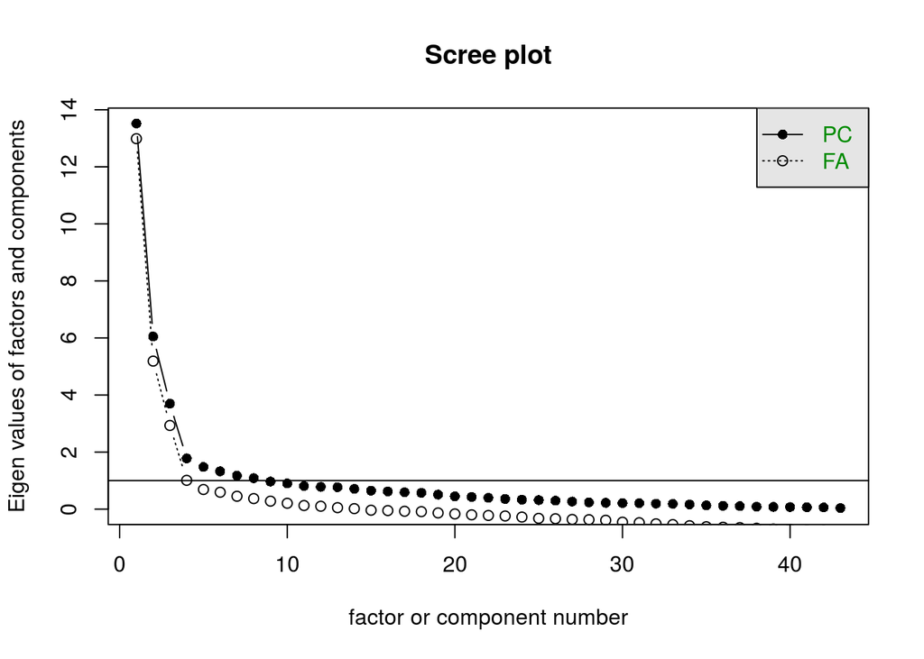

```
## Factor Analysis using method =  pa
## Call: fa(r = select(selfRateDat_lim2, -matches("SelfPop")), nfactors = 3,
##     rotate = "oblimin", scores = "tenBerge", fm = "pa", use = "pairwise.complete.obs")
## Standardized loadings (pattern matrix) based upon correlation matrix
##                    item   PA1   PA2   PA3   h2   u2 com
## insecure_Self        24  0.86             0.74 0.26 1.0
## lonely_Self          28  0.85             0.69 0.31 1.0
## depressed_Self       17  0.85             0.70 0.30 1.0
## awkward_Self          5  0.83             0.63 0.37 1.0
## loner_Self           29  0.71             0.64 0.36 1.2
## plain_Self           32  0.68             0.46 0.54 1.1
## grumpy_Self          21  0.66  0.47       0.59 0.41 2.0
## boring _Self          6  0.65             0.46 0.54 1.0
## shy_Self             39  0.63             0.50 0.50 1.6
## pushover_Self        35  0.59             0.35 0.65 1.0
## jealous_Self         25  0.55  0.36       0.38 0.62 1.8
## confident_Self       11 -0.54  0.42       0.73 0.27 2.2
## poor_Self            33  0.54       -0.29 0.46 0.54 1.7
## dependent_Self       16  0.41             0.15 0.85 1.8
## controlling_Self     13        0.78       0.59 0.41 1.1
## bossy_Self            7        0.78       0.64 0.36 1.3
## cool_Self            14        0.62  0.30 0.69 0.31 1.8
## risky_Self           36        0.60       0.36 0.64 1.1
## admired_Self          1 -0.29  0.59       0.66 0.34 1.8
## daring_Self          15        0.56       0.39 0.61 1.1
## adventurous_Self      2        0.54       0.52 0.48 1.8
## leader_Self          27        0.53       0.49 0.51 1.7
## popular_Self         34 -0.45  0.53       0.72 0.28 2.3
## social_Self          40 -0.45  0.52       0.71 0.29 2.2
## flirty_Self          18 -0.38  0.52       0.53 0.47 1.8
## trendy_Self          43 -0.51  0.51       0.68 0.32 2.0
## selfish_Self         38  0.33  0.49 -0.40 0.49 0.51 2.7
## outgoing_Self        30 -0.37  0.49       0.52 0.48 2.0
## stubborn_Self        41  0.32  0.48       0.24 0.76 1.7
## attractive_Self       4 -0.35  0.46  0.31 0.62 0.38 2.7
## lazy_Self            26  0.34  0.37       0.28 0.72 2.6
## funny_Self           19 -0.31  0.35       0.42 0.58 2.9
## athletic_Self         3                   0.19 0.81 2.7
## considerate_Self     12              0.85 0.66 0.34 1.1
## helpful_Self         22              0.85 0.71 0.29 1.1
```

[output cut: 28 more lines]

```
## The root mean square of the residuals (RMSR) is  0.06
## The df corrected root mean square of the residuals is  0.06
##
## The harmonic number of observations is  99 with the empirical chi square  614.34  with prob <  1
## The total number of observations was  100  with MLE Chi Square =  1180.47  with prob <  3.4e-19
##
## Tucker Lewis Index of factoring reliability =  0.796
## RMSEA index =  0.092  and the 90 % confidence intervals are  0.064 NA
## BIC =  -2397.75
## Fit based upon off diagonal values = 0.97
## Measures of factor score adequacy
##                                                 PA1  PA2  PA3
## Correlation of scores with factors             0.98 0.97 0.97
## Multiple R square of scores with factors       0.96 0.94 0.93
## Minimum correlation of possible factor scores  0.92 0.88 0.86
```

I’m going to trim just a couple items for low loadings, or high cross loadings

```
athletic_Self         3                   0.19 0.81 2.7
trendy_Self          43 -0.51  0.51       0.68 0.32 2.0
selfish_Self         38  0.33  0.49 -0.40 0.49 0.51 2.7
```

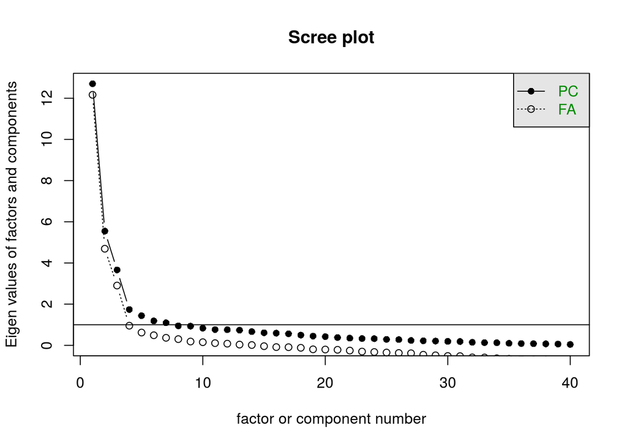

```
## Factor Analysis using method =  pa
## Call: fa(r = select(selfRateDat_lim3, -matches("SelfPop")), nfactors = 3,
##     rotate = "oblimin", scores = "tenBerge", fm = "pa", use = "pairwise.complete.obs")
## Standardized loadings (pattern matrix) based upon correlation matrix
##                    item   PA1   PA2   PA3   h2   u2 com
## lonely_Self          27  0.83             0.69 0.31 1.0
## depressed_Self       16  0.83             0.69 0.31 1.0
## insecure_Self        23  0.83             0.73 0.27 1.0
## awkward_Self          4  0.82             0.62 0.38 1.0
## grumpy_Self          20  0.69  0.44       0.59 0.41 1.9
## loner_Self           28  0.67             0.65 0.35 1.3
## plain_Self           31  0.66             0.46 0.54 1.1
## boring _Self          5  0.64             0.46 0.54 1.0
## pushover_Self        34  0.60             0.36 0.64 1.0
## shy_Self             37  0.59 -0.31       0.51 0.49 1.9
## jealous_Self         24  0.58  0.34       0.39 0.61 1.7
## poor_Self            32  0.55       -0.30 0.48 0.52 1.6
## confident_Self       10 -0.50  0.47       0.73 0.27 2.3
## dependent_Self       15  0.41             0.14 0.86 1.7
## lazy_Self            25  0.37  0.35       0.27 0.73 2.6
## controlling_Self     12        0.78       0.58 0.42 1.2
## bossy_Self            6        0.76       0.61 0.39 1.4
## cool_Self            13        0.66       0.68 0.32 1.5
## admired_Self          1        0.63       0.65 0.35 1.6
## risky_Self           35        0.62       0.37 0.63 1.2
## daring_Self          14        0.60       0.41 0.59 1.1
## adventurous_Self      2        0.59       0.52 0.48 1.5
## social_Self          38 -0.40  0.57       0.72 0.28 2.0
## popular_Self         33 -0.40  0.57       0.72 0.28 2.0
## flirty_Self          17 -0.33  0.57       0.54 0.46 1.6
## leader_Self          26        0.55       0.48 0.52 1.4
## outgoing_Self        29 -0.32  0.53       0.53 0.47 1.7
## attractive_Self       3 -0.32  0.50  0.30 0.62 0.38 2.4
## stubborn_Self        39  0.34  0.46       0.23 0.77 1.8
## funny_Self           18        0.39       0.42 0.58 2.6
## considerate_Self     11              0.85 0.67 0.33 1.1
## helpful_Self         21              0.83 0.70 0.30 1.1
## caring_Self           8              0.76 0.58 0.42 1.0
## genuine_Self         19              0.76 0.55 0.45 1.0
## humble_Self          22              0.66 0.44 0.56 1.4
```

[output cut: 25 more lines]

```
## The root mean square of the residuals (RMSR) is  0.06
## The df corrected root mean square of the residuals is  0.06
##
## The harmonic number of observations is  99 with the empirical chi square  520.47  with prob <  1
## The total number of observations was  100  with MLE Chi Square =  1017.64  with prob <  1.9e-17
##
## Tucker Lewis Index of factoring reliability =  0.804
## RMSEA index =  0.092  and the 90 % confidence intervals are  0.064 NA
## BIC =  -2035.59
## Fit based upon off diagonal values = 0.97
## Measures of factor score adequacy
##                                                 PA1  PA2  PA3
## Correlation of scores with factors             0.98 0.97 0.96
## Multiple R square of scores with factors       0.95 0.94 0.92
## Minimum correlation of possible factor scores  0.91 0.88 0.85
```

These clusters of items may be related to status We can correlate self rated accepted and controversial status with the factor scores to start exploring this.

### Correlations

In the output below, SelfPop_1 is controversial, and SelfPop_2 is accepted.

Controversial status is significantly positively correlated with dynamism and negativity, and negatively with prosociality.

Accepted status is significantly positively associated with dynamism and negatively with negativity, and non-significantly correlated with prosociality.

```
## Call:corr.test(x = as.data.frame(selfPopDat), y = as.data.frame(predict(selfRateFA,
##     selfRateDat_nopop_imputed, missing = T, use = "pairwise.complete.obs")),
##     use = "pairwise.complete.obs", adjust = "none")
## Correlation matrix
##              V1   V2    V3
## SelfPop_1  0.22 0.45 -0.25
## SelfPop_2 -0.57 0.40  0.16
## Sample Size
##            V1  V2  V3
## SelfPop_1  98  98  98
## SelfPop_2 100 100 100
##             V1 V2   V3
## SelfPop_1 0.03  0 0.01
## SelfPop_2 0.00  0 0.12
##
##  To see confidence intervals of the correlations, print with the short=FALSE option
```

Grain of salt: No correction for multiple comparison here.

Slightly bigger grain of salt: 8 folks are missing a rating on a couple items here and there, so I impute the mean so we can get predicted factor scores. This means that significance values and CIs close to threshold below should be treated lightly (but it doesn’t change things too much).

This gets more interesting in the regressions.

### Regressing Controversial Status

Here’s the raw output for regressing controversial status on the component scores – see below for a table with CIs.

```
##
## Call: rlm(formula = selfPopDat[, c("SelfPop_1")] ~ predict(selfRateFA,
##     selfRateDat_nopop_imputed))
## Residuals:
##      Min       1Q   Median       3Q      Max
## -2.92187 -0.79252 -0.09251  0.73451  3.46324
##
## Coefficients:
##                                                 Value   Std. Error t value
## (Intercept)                                      2.3636  0.1394    16.9610
## predict(selfRateFA, selfRateDat_nopop_imputed)1  0.3624  0.1406     2.5778
## predict(selfRateFA, selfRateDat_nopop_imputed)2  0.7674  0.1396     5.4958
## predict(selfRateFA, selfRateDat_nopop_imputed)3 -0.4464  0.1400    -3.1889
##
## Residual standard error: 1.137 on 94 degrees of freedom
##   (2 observations deleted due to missingness)
```

Results from bootstrap estimates: Controversial status is significantly negatively predicted by the prosocial component and significantly positively predicited by the dominant-agressive component.

Controversial status relation with component scores, bootstrapped CIs

| component | est | lower 95% | upper 95% |
| --- | --- | --- | --- |
| 1 | 0.36 | 0.09 | 0.61 |
| 2 | 0.77 | 0.43 | 1.10 |
| 3 | -0.45 | -0.78 | -0.18 |

### Regressing Accepted Status

Here’s the raw output for an rlm of accepted status on the component scores. Again, scroll down for a nice table.

```
##
## Call: rlm(formula = selfPopDat[, c("SelfPop_2")] ~ predict(selfRateFA,
##     selfRateDat_nopop_imputed))
## Residuals:
##      Min       1Q   Median       3Q      Max
## -3.07814 -0.64866  0.04891  0.59934  2.07161
##
## Coefficients:
##                                                 Value   Std. Error t value
## (Intercept)                                      3.5627  0.1197    29.7527
## predict(selfRateFA, selfRateDat_nopop_imputed)1 -0.9505  0.1204    -7.8941
## predict(selfRateFA, selfRateDat_nopop_imputed)2  0.7930  0.1205     6.5830
## predict(selfRateFA, selfRateDat_nopop_imputed)3  0.2429  0.1204     2.0174
##
## Residual standard error: 0.9 on 96 degrees of freedom
```

Accepted status is significantly predicted by higher prosociality, less depression/negativity, and more dominance/aggression.

Accepted status relation with component scores, bootstrapped CIs

| component | est | lower 95% | upper 95% |
| --- | --- | --- | --- |
| 1 | -0.95 | -1.21 | -0.68 |
| 2 | 0.79 | 0.45 | 1.04 |
| 3 | 0.24 | 0.04 | 0.43 |

### What has EFA told us?

Well, we have three factors that are helpfully related to self reported status. This is what we want. All three factors seem relevant.

### Scale scores

The above was all tested with factor scores, but we’ll be using scale scores. Let’s test that:

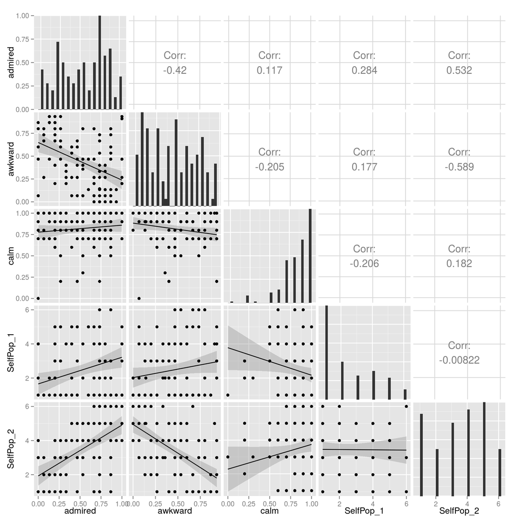

## Which Cleaned Set to Use?

Looking at the distribution of both sets of items (those cleaned by removing items with bad loadings, versus those cleaned by removing skewed items first) indicates that both have a factor that has a skewed distribution. So we haven’t gained anything there. Additionally, both seem to predict the two different kinds status. Especially because the prosocial factor in the first cleaned set has more items, for the fMRI paradigm it makes sense to use that one.

Below I’ll test the factor scores (binarized, as we’ll get off the scanner) to predict the two status types.

See raw summary, and below that, tables of bootstrapped CIs.

```
##
## Call: rlm(formula = SelfPop_1 ~ 1 + agressive + awkward + calm, data = selfRateFAScaleScores)
## Residuals:
##     Min      1Q  Median      3Q     Max
## -2.5651 -0.6330 -0.2648  0.7861  3.3393
##
## Coefficients:
##             Value   Std. Error t value
## (Intercept)  1.8999  0.7843     2.4225
## agressive    3.2749  0.5502     5.9524
## awkward     -0.0978  0.4259    -0.2297
## calm        -0.6259  0.7700    -0.8128
##
## Residual standard error: 1.06 on 94 degrees of freedom
##   (2 observations deleted due to missingness)
```

```
##
## Call: rlm(formula = SelfPop_2 ~ 1 + agressive + awkward + calm, data = selfRateFAScaleScores)
## Residuals:
##     Min      1Q  Median      3Q     Max
## -3.0069 -1.0585  0.2344  1.0033  2.5296
##
## Coefficients:
##             Value   Std. Error t value
## (Intercept)  3.9186  0.8191     4.7840
## agressive    0.7777  0.5734     1.3563
## awkward     -2.9178  0.4441    -6.5701
## calm         0.7352  0.8023     0.9164
##
## Residual standard error: 1.554 on 96 degrees of freedom
```

```
## Call:corr.test(x = select(selfRateFAScaleScores, matches("SelfPop")),
##     y = select(selfRateFAScaleScores, agressive, awkward, calm),
##     use = "pairwise.complete.obs", method = "kendall", adjust = "none")
## Correlation matrix
##           agressive awkward  calm
## SelfPop_1      0.42    0.05 -0.34
## SelfPop_2      0.02   -0.47  0.18
## Sample Size
##           agressive awkward calm
## SelfPop_1        98      98   98
## SelfPop_2       100     100  100
##           agressive awkward calm
## SelfPop_1      0.00    0.64 0.00
## SelfPop_2      0.84    0.00 0.07
##
##  To see confidence intervals of the correlations, print with the short=FALSE option
```

Controversial status relation with scale scores, bootstrapped CIs

|  | est | lower 95% | upper 95% |
| --- | --- | --- | --- |
| d[, 2:col]agressive | 3.27 | 1.92 | 4.56 |
| d[, 2:col]awkward | -0.10 | -0.78 | 0.65 |
| d[, 2:col]calm | -0.63 | -2.76 | 0.82 |

Accepted status relation with scale scores, bootstrapped CIs

|  | est | lower 95% | upper 95% |
| --- | --- | --- | --- |
| d[, 2:col]agressive | 0.78 | -0.70 | 2.01 |
| d[, 2:col]awkward | -2.92 | -3.70 | -2.06 |
| d[, 2:col]calm | 0.74 | -1.13 | 2.04 |

### A Little CFA

```
## calm=~calm_Self+caring_Self+considerate_Self+fair_Self+friendly_Self+genuine_Self+giving_Self+helpful_Self+honest_Self+humble_Self+loyal_Self+motivated_Self+nice_Self+respectful_Self+rulefollower_Self+smart_Self+studious_Self+sympathetic_Self+trustworthy_Self+welcoming_Self
## awkward=~awkward_Self+boring_Self+confident_Self+depressed_Self+insecure_Self+lonely_Self+loner_Self+plain_Self+pushover_Self+shy_Self+ugly_Self
## agressive=~agressive_Self+bossy_Self+controlling_Self+lazy_Self+risky_Self+rude_Self+selfish_Self+snobby_Self+stubborn_Self
```

```
## lavaan (0.5-18) converged normally after  48 iterations
##
##                                                   Used       Total
##   Number of observations                            94         100
##
##   Estimator                                         ML
##   Minimum Function Test Statistic             1417.575
##   Degrees of freedom                               737
##   P-value (Chi-square)                           0.000
##
## Model test baseline model:
##
##   Minimum Function Test Statistic             3402.436
##   Degrees of freedom                               780
##   P-value                                        0.000
##
## User model versus baseline model:
##
##   Comparative Fit Index (CFI)                    0.740
##   Tucker-Lewis Index (TLI)                       0.725
##
## Loglikelihood and Information Criteria:
##
##   Loglikelihood user model (H0)              -5440.336
##   Loglikelihood unrestricted model (H1)      -4731.549
##
##   Number of free parameters                         83
##   Akaike (AIC)                               11046.672
##   Bayesian (BIC)                             11257.766
##   Sample-size adjusted Bayesian (BIC)        10995.735
##
## Root Mean Square Error of Approximation:
##
##   RMSEA                                          0.099
##   90 Percent Confidence Interval          0.091  0.107
##   P-value RMSEA <= 0.05                          0.000
##
## Standardized Root Mean Square Residual:
##
##   SRMR                                           0.105
```

[output cut: 88 more lines]

```
##     pushover_Self     1.779    0.268                      1.779    0.661
##     shy_Self          1.846    0.280                      1.846    0.624
##     ugly_Self         1.219    0.186                      1.219    0.578
##     agressive_Slf     0.865    0.146                      0.865    0.432
##     bossy_Self        0.900    0.156                      0.900    0.397
##     contrllng_Slf     1.061    0.174                      1.061    0.481
##     lazy_Self         1.605    0.244                      1.605    0.721
##     risky_Self        1.708    0.255                      1.708    0.820
##     rude_Self         0.598    0.106                      0.598    0.376
##     selfish_Self      0.922    0.151                      0.922    0.495
##     snobby_Self       0.712    0.132                      0.712    0.330
##     stubborn_Self     2.129    0.316                      2.129    0.851
##     calm              0.512    0.156                      1.000    1.000
##     awkward           1.732    0.391                      1.000    1.000
##     agressive         1.138    0.274                      1.000    1.000
```

Ultimately, when we reduce the items to scale scores, only the strongest predictors survive (though note the correlations above). Aggression, all else equal, predicts Controversial High Status. Extraversion, all else equal, predicts accepted status.

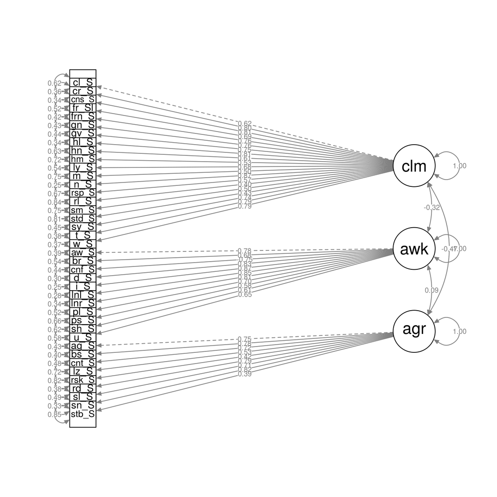

Estimates of reliability vary below between the CFA and the alphas on the raw scales, but I’m not sure why.

```
##             calm   awkward agressive     total
## alpha  0.9411144 0.8572672 0.8704910 0.7542231
## omega  0.9411100 0.9021307 0.8727198 0.8491448
## omega2 0.9411100 0.9021307 0.8727198 0.8491448
## omega3 0.9267801 0.8933607 0.8618855 0.7556667
## avevar 0.4525898 0.5607947 0.4443711 0.4926990
```

```
##
## Reliability analysis
## Call: alpha(x = dataCFA[, itemScaleGroupsCFA$item[itemScaleGroupsCFA$maxPA ==
##     "PA1"]], check.keys = T)
##
##   raw_alpha std.alpha G6(smc) average_r S/N   ase mean  sd
##       0.94      0.94    0.96      0.44  16 0.016  4.6 0.8
##
##  lower alpha upper     95% confidence boundaries
## 0.91 0.94 0.97
##
##  Reliability if an item is dropped:
##                   raw_alpha std.alpha G6(smc) average_r S/N alpha se
## calm_Self              0.94      0.94    0.96      0.45  15    0.017
## caring_Self            0.93      0.94    0.95      0.44  15    0.017
## considerate_Self       0.93      0.94    0.95      0.43  15    0.017
## fair_Self              0.94      0.94    0.95      0.44  15    0.017
## friendly_Self          0.93      0.94    0.95      0.44  15    0.017
## genuine_Self           0.93      0.94    0.95      0.44  15    0.017
## giving_Self            0.93      0.94    0.95      0.44  15    0.017
## helpful_Self           0.93      0.94    0.95      0.44  15    0.017
## honest_Self            0.94      0.94    0.96      0.45  15    0.017
## humble_Self            0.94      0.94    0.96      0.45  16    0.017
## loyal_Self             0.93      0.94    0.95      0.44  15    0.017
## motivated_Self         0.94      0.94    0.96      0.45  16    0.017
## nice_Self              0.93      0.94    0.95      0.43  14    0.017
## respectful_Self        0.94      0.94    0.96      0.45  15    0.017
## rulefollower_Self      0.94      0.94    0.96      0.46  16    0.016
## smart_Self             0.94      0.94    0.96      0.46  16    0.017
## studious_Self          0.94      0.94    0.96      0.46  16    0.016
## sympathetic_Self       0.93      0.94    0.95      0.44  15    0.017
## trustworthy_Self       0.93      0.94    0.95      0.44  15    0.017
## welcoming_Self         0.93      0.94    0.95      0.44  15    0.017
##
##  Item statistics
##                     n raw.r std.r r.cor r.drop mean   sd
## calm_Self          99  0.65  0.65  0.63   0.60  4.4 1.17
## caring_Self       100  0.76  0.77  0.76   0.73  4.7 1.09
## considerate_Self  100  0.79  0.80  0.80   0.76  4.8 1.03
## fair_Self         100  0.72  0.71  0.70   0.67  4.6 1.26
```

[output cut: 24 more lines]

```
## genuine_Self      0.00 0.04 0.08 0.29 0.29 0.30 0.00
## giving_Self       0.01 0.10 0.03 0.31 0.28 0.27 0.00
## helpful_Self      0.00 0.04 0.06 0.27 0.34 0.29 0.00
## honest_Self       0.01 0.06 0.11 0.20 0.37 0.24 0.01
## humble_Self       0.04 0.02 0.15 0.31 0.29 0.19 0.00
## loyal_Self        0.02 0.04 0.08 0.17 0.39 0.30 0.00
## motivated_Self    0.03 0.07 0.08 0.28 0.31 0.22 0.01
## nice_Self         0.00 0.03 0.05 0.21 0.43 0.28 0.00
## respectful_Self   0.02 0.02 0.05 0.19 0.42 0.30 0.00
## rulefollower_Self 0.04 0.08 0.11 0.29 0.27 0.21 0.00
## smart_Self        0.00 0.04 0.02 0.21 0.43 0.30 0.02
## studious_Self     0.02 0.07 0.13 0.31 0.24 0.23 0.00
## sympathetic_Self  0.04 0.04 0.11 0.21 0.35 0.24 0.01
## trustworthy_Self  0.01 0.03 0.04 0.25 0.38 0.29 0.00
## welcoming_Self    0.02 0.05 0.11 0.21 0.40 0.21 0.00
```

```
##
## Reliability analysis
## Call: alpha(x = dataCFA[, itemScaleGroupsCFA$item[itemScaleGroupsCFA$maxPA ==
##     "PA2"]], check.keys = T)
##
##   raw_alpha std.alpha G6(smc) average_r S/N   ase mean  sd
##       0.93      0.93    0.94      0.54  13 0.024  3.2 1.2
##
##  lower alpha upper     95% confidence boundaries
## 0.88 0.93 0.98
##
##  Reliability if an item is dropped:
##                 raw_alpha std.alpha G6(smc) average_r S/N alpha se
## awkward_Self         0.92      0.92    0.92      0.53  11    0.027
## boring_Self          0.92      0.92    0.93      0.55  12    0.026
## confident_Self-      0.92      0.92    0.93      0.54  12    0.026
## depressed_Self       0.92      0.92    0.92      0.53  11    0.027
## insecure_Self        0.92      0.92    0.92      0.52  11    0.027
## lonely_Self          0.92      0.92    0.92      0.52  11    0.027
## loner_Self           0.92      0.92    0.92      0.53  11    0.027
## plain_Self           0.92      0.92    0.93      0.55  12    0.026
## pushover_Self        0.93      0.93    0.93      0.56  13    0.026
## shy_Self             0.93      0.93    0.93      0.56  13    0.026
## ugly_Self            0.92      0.92    0.93      0.55  12    0.026
##
##  Item statistics
##                   n raw.r std.r r.cor r.drop mean  sd
## awkward_Self    100  0.79  0.79  0.78   0.74  3.6 1.7
## boring_Self     100  0.72  0.72  0.69   0.66  2.8 1.5
## confident_Self-  99  0.76  0.75  0.73   0.70  3.3 1.6
## depressed_Self   99  0.83  0.82  0.81   0.78  3.0 1.7
## insecure_Self   100  0.86  0.85  0.85   0.82  3.5 1.8
## lonely_Self     100  0.85  0.85  0.84   0.81  3.2 1.7
## loner_Self      100  0.84  0.84  0.83   0.79  3.1 1.7
## plain_Self       99  0.73  0.73  0.69   0.66  3.2 1.6
## pushover_Self    99  0.66  0.66  0.61   0.58  3.0 1.7
## shy_Self        100  0.67  0.67  0.62   0.60  3.9 1.7
## ugly_Self       100  0.69  0.70  0.66   0.63  2.4 1.4
##
## Non missing response frequency for each item
##                   1    2    3    4    5    6 miss
## awkward_Self   0.18 0.12 0.10 0.26 0.20 0.14 0.00
## boring_Self    0.27 0.23 0.15 0.21 0.09 0.05 0.00
## confident_Self 0.11 0.14 0.18 0.22 0.20 0.14 0.01
## depressed_Self 0.26 0.18 0.18 0.15 0.12 0.10 0.01
## insecure_Self  0.19 0.15 0.15 0.17 0.17 0.17 0.00
## lonely_Self    0.22 0.16 0.19 0.21 0.10 0.12 0.00
## loner_Self     0.25 0.18 0.14 0.18 0.13 0.12 0.00
## plain_Self     0.18 0.17 0.22 0.18 0.14 0.10 0.01
## pushover_Self  0.27 0.18 0.10 0.21 0.17 0.06 0.01
## shy_Self       0.14 0.12 0.13 0.19 0.20 0.22 0.00
## ugly_Self      0.35 0.27 0.17 0.10 0.07 0.04 0.00
```

```
##
## Reliability analysis
## Call: alpha(x = dataCFA[, itemScaleGroupsCFA$item[itemScaleGroupsCFA$maxPA ==
##     "PA3"]], check.keys = T)
##
##   raw_alpha std.alpha G6(smc) average_r S/N   ase mean sd
##       0.87      0.87    0.88      0.43 6.9 0.036  2.6  1
##
##  lower alpha upper     95% confidence boundaries
## 0.8 0.87 0.94
##
##  Reliability if an item is dropped:
##                  raw_alpha std.alpha G6(smc) average_r S/N alpha se
## agressive_Self        0.85      0.85    0.86      0.42 5.8    0.041
## bossy_Self            0.84      0.85    0.85      0.41 5.5    0.042
## controlling_Self      0.85      0.85    0.86      0.42 5.7    0.041
## lazy_Self             0.87      0.87    0.88      0.46 6.8    0.038
## risky_Self            0.87      0.88    0.88      0.47 7.1    0.038
## rude_Self             0.85      0.85    0.86      0.42 5.8    0.041
## selfish_Self          0.85      0.86    0.86      0.42 5.9    0.041
## snobby_Self           0.85      0.85    0.86      0.42 5.7    0.041
## stubborn_Self         0.87      0.88    0.88      0.47 7.1    0.037
##
##  Item statistics
##                    n raw.r std.r r.cor r.drop mean  sd
## agressive_Self    99  0.76  0.77  0.74   0.69  2.3 1.4
## bossy_Self       100  0.81  0.81  0.80   0.75  2.6 1.5
## controlling_Self 100  0.78  0.78  0.76   0.70  2.6 1.5
## lazy_Self         99  0.60  0.59  0.52   0.47  2.6 1.5
## risky_Self       100  0.54  0.54  0.45   0.42  2.9 1.4
## rude_Self        100  0.77  0.77  0.76   0.69  2.2 1.3
## selfish_Self      99  0.74  0.75  0.71   0.66  2.6 1.4
## snobby_Self       99  0.78  0.78  0.76   0.70  2.3 1.5
## stubborn_Self    100  0.56  0.55  0.47   0.42  3.5 1.6
##
## Non missing response frequency for each item
##                     1    2    3    4    5    6 miss
## agressive_Self   0.42 0.16 0.19 0.12 0.08 0.02 0.01
## bossy_Self       0.32 0.22 0.16 0.17 0.09 0.04 0.00
## controlling_Self 0.29 0.29 0.12 0.17 0.09 0.04 0.00
## lazy_Self        0.31 0.24 0.12 0.19 0.08 0.05 0.01
## risky_Self       0.21 0.22 0.23 0.18 0.12 0.04 0.00
## rude_Self        0.43 0.23 0.15 0.12 0.07 0.00 0.00
## selfish_Self     0.28 0.24 0.16 0.19 0.10 0.02 0.01
## snobby_Self      0.43 0.20 0.09 0.17 0.08 0.02 0.01
## stubborn_Self    0.15 0.13 0.22 0.20 0.18 0.12 0.00
```